# EDA-Challenge.Rmd

Jessica V

2024-02-25

```r
library(tidyverse)
```

#Here I am reading the dataset “https://raw.githubusercontent.com/difiore/ada-2024-datasets/main/data-wrangling.csv”

```r
f <- "https://raw.githubusercontent.com/difiore/ada-2024-datasets/main/data-wrangling.csv"

d <- read_csv(f, col_names = TRUE)
```

#Here we can look at the variables it contains

```r
names(d)
```

```
##  [1] "Scientific_Name"         "Family"
##  [3] "Genus"                   "Species"
##  [5] "Brain_Size_Species_Mean" "Body_mass_male_mean"
##  [7] "Body_mass_female_mean"   "MeanGroupSize"
##  [9] "AdultMales"              "AdultFemale"
## [11] "GR_MidRangeLat_dd"       "Precip_Mean_mm"
## [13] "Temp_Mean_degC"          "HomeRange_km2"
## [15] "DayLength_km"            "Fruit"
## [17] "Leaves"                  "Fauna"
## [19] "Canine_Dimorphism"       "Feed"
## [21] "Move"                    "Rest"
## [23] "Social"
```

# Here I an creating a new variable named BSD (body size dimorphism) which is the ratio of average male to female body mass.

# I need to use the following Body_mass_male_mean” “Body_mass_female_mean”

```r
BSD <- d$ratio <- d$Body_mass_male_mean/d$Body_mass_female_mean

BSD
```

```
##   [1] 1.9276730 1.0952381 1.3170290 1.5389151 1.2747253 1.3364486 1.7729393
##   [8] 1.2840691 0.9593496        NA 1.0512498 1.0179487 0.8413462 1.1190400
##  [15] 1.0143266 1.0196078 0.9252275 0.9705240 1.0672154 1.0520446 0.8462127
##  [22] 1.0910633 1.1908302 1.1191339 1.1979167 1.1660517 1.0902090 1.0582524
##  [29] 1.0669456 0.9202899 1.0578512 1.0662393 0.9166667        NA        NA
##  [36] 0.9473684 0.9875776        NA 1.1029836 0.9016393 1.3886463 1.3590454
##  [43] 1.3485738 1.2262940 1.2527346 1.6784452 1.8269962 1.7218182 1.7741935
##  [50] 1.6372275 1.5607032 1.6666667 1.4895833 1.3333333 1.2413793 1.6339286
##  [57] 1.7304348 1.6401469 1.7215514 1.7796610 1.5657277 1.4735111 1.4689655
##  [64]        NA 1.7576531 1.3623693 1.2099448 1.0071942 1.0472973 1.4478447
##  [71] 1.4182001 1.3307027 1.2787318 1.2887711 1.1927711 1.4016173 1.1662050
##  [78] 1.0522088 1.9076923 1.0477861 1.0093897        NA 1.1851852 0.9642995
##  [85] 0.9670782 0.8921576 1.0206186 0.9559471 1.0218579 1.0996169 0.9764151
##  [92] 1.0163043 1.0654255 1.0424077 1.0875912 1.6666667 2.3832168        NA
##  [99] 1.1164179 0.9816147 1.6538462 1.0103093 0.9577703 1.0795964 1.0528000
```

[output cut: 16 more lines]

```r
d$BSDcol <- c(BSD)
```

# Here I need to create a new variable named sex_ratio, which is the ratio of the number of adult females to adult males in a typical group

```r
d$ratio <- d$AdultFemale/d$AdultMales
sex_ratio <- d$ratio <- d$AdultFemale/d$AdultMales
sex_ratio
```

```
##   [1]         NA  1.0000000  1.0000000  1.4347826  1.6058394  2.1724138
##   [7]  1.1298701  1.2941176  1.0000000  1.0000000         NA  1.0000000
##  [13]  1.0000000  1.0000000  1.0000000         NA  2.0588235         NA
##  [19]         NA  0.5750000  1.0000000  1.0000000  1.0142857         NA
##  [25]  1.0000000         NA         NA         NA  1.0000000  1.0000000
##  [31]  1.0000000  2.0000000         NA  1.6666667  0.5000000  1.1785714
##  [37]  1.2608696  0.5000000  0.6666667  0.6666667  1.7105263  1.3611111
##  [43]  1.4705882  1.9714286         NA  3.7500000  4.7500000         NA
##  [49]  2.7777778         NA  8.5000000  4.0000000  3.0000000  7.0000000
##  [55]         NA         NA         NA  8.8000000  1.9000000  1.0000000
##  [61]  5.0000000  4.8879310  5.0000000         NA         NA         NA
##  [67]  1.0000000  1.0000000  6.0000000  1.8780488         NA         NA
##  [73]  2.0000000  1.9333333  1.0000000  2.6086957         NA  1.0000000
##  [79]  6.9333333  0.8571429         NA  0.8333333  0.9079903  1.1666667
##  [85]  0.9117647  1.0000000  1.0000000  0.6341463  0.9466667         NA
```

[output cut: 21 more lines]

## Here I need to create a new variable name DI (for “defensibility index”), which is the ratioo of dat range lendg to the diameter of the home range

# home range here is a circel calculated AREA= pixr^2

# diameter = 2(sqrt(Area/pi))

```r
d$diametercol <- (2*(sqrt((d$HomeRange_km2)/pi)))
DI <- d$ratio <- d$DayLength_km/d$diametercol

d
```

```
## # A tibble: 213 × 26
##    Scientific_Name             Family       Genus Species Brain_Size_Species_M…¹
##    <chr>                       <chr>        <chr> <chr>                    <dbl>
##  1 Allenopithecus_nigroviridis Cercopithec… Alle… nigrov…                   58.0
##  2 Allocebus_trichotis         Cercopithec… Allo… tricho…                   NA
##  3 Alouatta_belzebul           Atelidae     Alou… belzeb…                   52.8
##  4 Alouatta_caraya             Atelidae     Alou… caraya                    52.6
##  5 Alouatta_guariba            Atelidae     Alou… guariba                   51.7
##  6 Alouatta_palliata           Atelidae     Alou… pallia…                   49.9
##  7 Alouatta_pigra              Atelidae     Alou… pigra                     51.1
##  8 Alouatta_seniculus          Atelidae     Alou… senicu…                   55.2
##  9 Aotus_azarai                Cebidae      Aotus azarai                    20.7
## 10 Aotus_brumbacki             Cebidae      Aotus brumba…                   NA
## # ℹ 203 more rows
## # ℹ abbreviated name: ¹Brain_Size_Species_Mean
## # ℹ 21 more variables: Body_mass_male_mean <dbl>, Body_mass_female_mean <dbl>,
## #   MeanGroupSize <dbl>, AdultMales <dbl>, AdultFemale <dbl>,
## #   GR_MidRangeLat_dd <dbl>, Precip_Mean_mm <dbl>, Temp_Mean_degC <dbl>,
## #   HomeRange_km2 <dbl>, DayLength_km <dbl>, Fruit <dbl>, Leaves <chr>,
## #   Fauna <chr>, Canine_Dimorphism <dbl>, Feed <dbl>, Move <dbl>, Rest <dbl>, …
```

# Here I have to plot the relationship between day range length and time spent moving, for these primate species overall.

Do species that spend more time moving travel farther overall? How about within any particular primate family? Should you transform either of these variables?

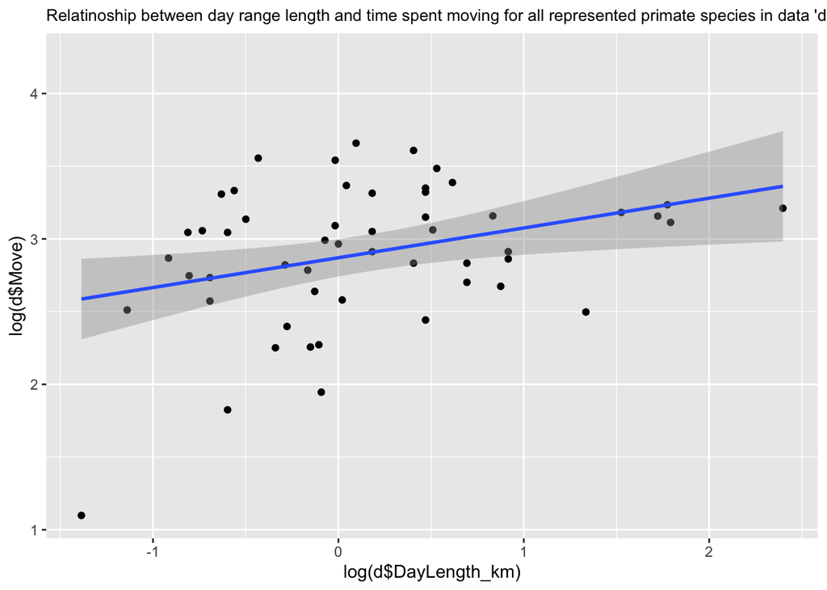

```r
d %>%
    ggplot(aes(x = log(d$DayLength_km), y = log(d$Move))) +
    geom_point() + ggtitle ("Relatinoship between day range length and time spent moving for all represented primate species in data 'd'") + theme(plot.title = element_text(size=10)) + geom_smooth(method = "lm", fullrange = FALSE, na.rm = TRUE)
```

## According to this plot ^ species that spend more time moving travel further overall. When splitting this by family we see that this hold true for : Atelidae, Cebidae, Hylobatidae # Here I have to plot the relationship between day range length and time spent moving, for these primate species by family

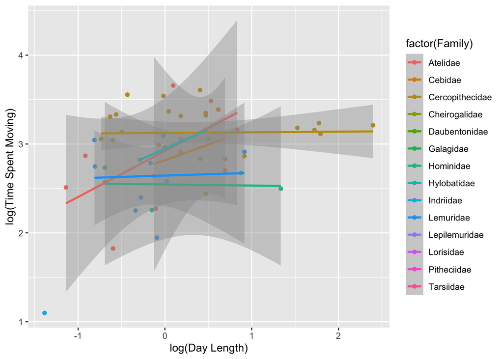

```r
p <- ggplot(data = d, aes(x = log(d$DayLength_km), y = log(d$Move),
    color = factor(Family)))
p <- p + geom_point(na.rm = TRUE)
p <- p + xlab("log(Day Length)") + ylab("log(Time Spent Moving)")
p <- p + geom_smooth(method = "lm", fullrange = FALSE, na.rm = TRUE)
p
```

# OR like this

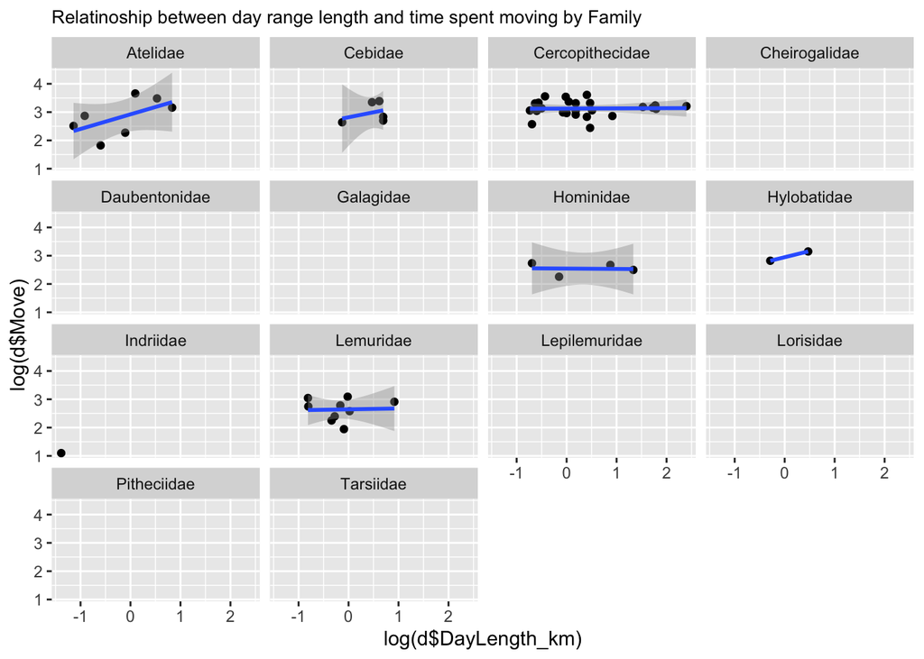

```r
d %>%
    ggplot(aes(x = log(d$DayLength_km), y = log(d$Move))) +
    geom_point() + ggtitle ("Relatinoship between day range length and time spent moving by Family") + theme(plot.title = element_text(size=10)) + facet_wrap(~Family, ncol = 4) + theme(legend.position = "none") + geom_smooth(method = "lm", fullrange = FALSE, na.rm = TRUE)
```

#5 Plot the relationship between day range length and time group size, overall and by family. Do species that live in larger groups travel farther overall? How about within any particular primate family? Should you transform either of these variables?

Overall primates that travel live in larger groups travel further

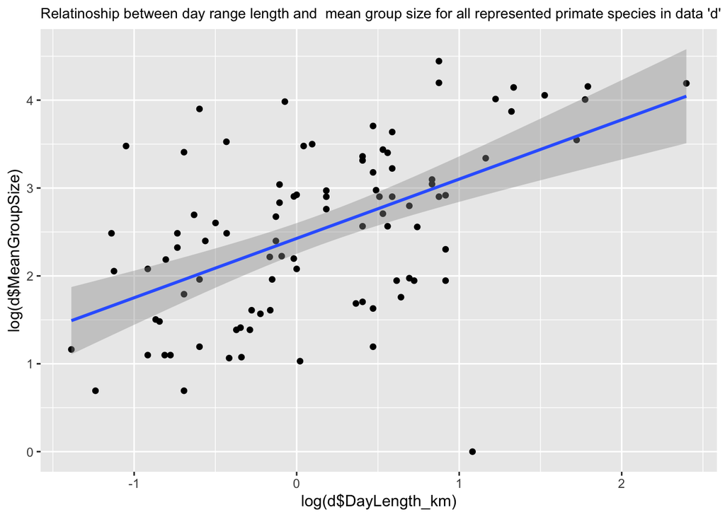

```r
d %>%
    ggplot(aes(x = log(d$DayLength_km), y = log(d$MeanGroupSize))) +
    geom_point() + ggtitle ("Relatinoship between day range length and  mean group size for all represented primate species in data 'd'") + theme(plot.title = element_text(size=10)) + geom_smooth(method = "lm", fullrange = FALSE, na.rm = TRUE)
```

#5 part 2

Primates who live in larger goups tend to travel further by family with the exception of Hylobatidae.

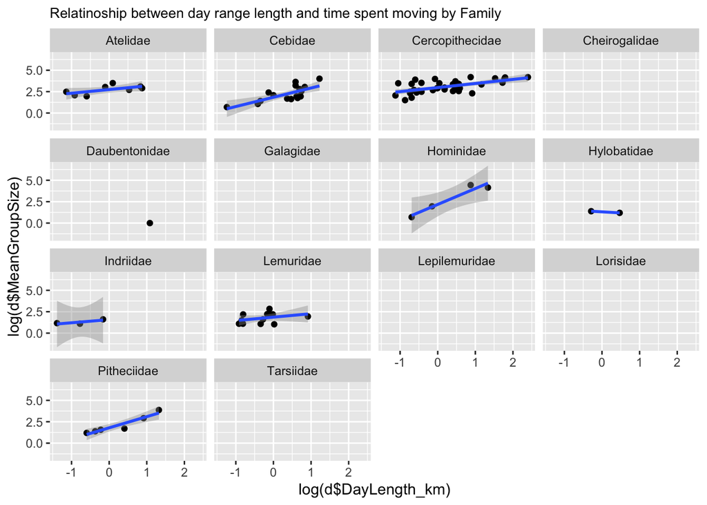

```r
d %>%
    ggplot(aes(x = log(d$DayLength_km), y = log(d$MeanGroupSize))) +
    geom_point() + ggtitle ("Relatinoship between day range length and time spent moving by Family") + theme(plot.title = element_text(size=10)) + facet_wrap(~Family, ncol = 4) + theme(legend.position = "none") + geom_smooth(method = "lm", fullrange = FALSE, na.rm = TRUE)
```

#6 Here I plot the relationship between body size dimorphism and canine size dimorphism overall.

Do taxa with greater size dimorphism also show greater canine dimorphism? overall species with greater size dimorphism also show greater canine dimorphism, this does not hold true for each family.

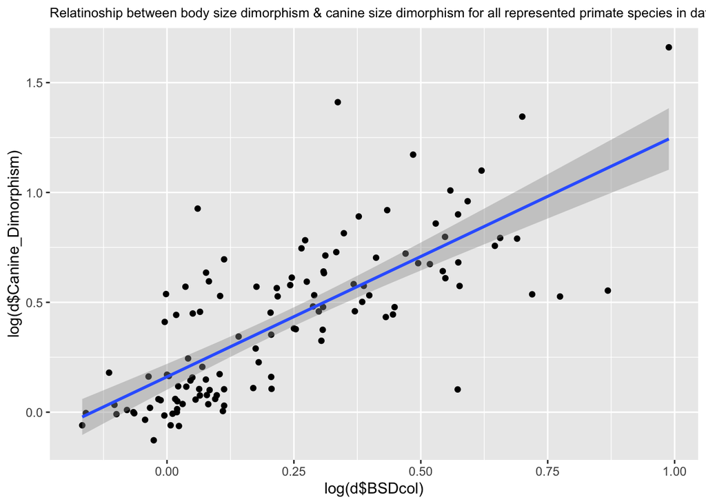

```r
d %>%
    ggplot(aes(x = log(d$BSDcol), y = log(d$Canine_Dimorphism))) +
    geom_point() + ggtitle ("Relatinoship between body size dimorphism & canine size dimorphism for all represented primate species in data 'd'") + theme(plot.title = element_text(size=9.5))  + geom_smooth(method = "lm", fullrange = FALSE, na.rm = TRUE)
```

# #6 part 2 Here I plot the relationship between body size dimorphism and canine size dimorphism by family.

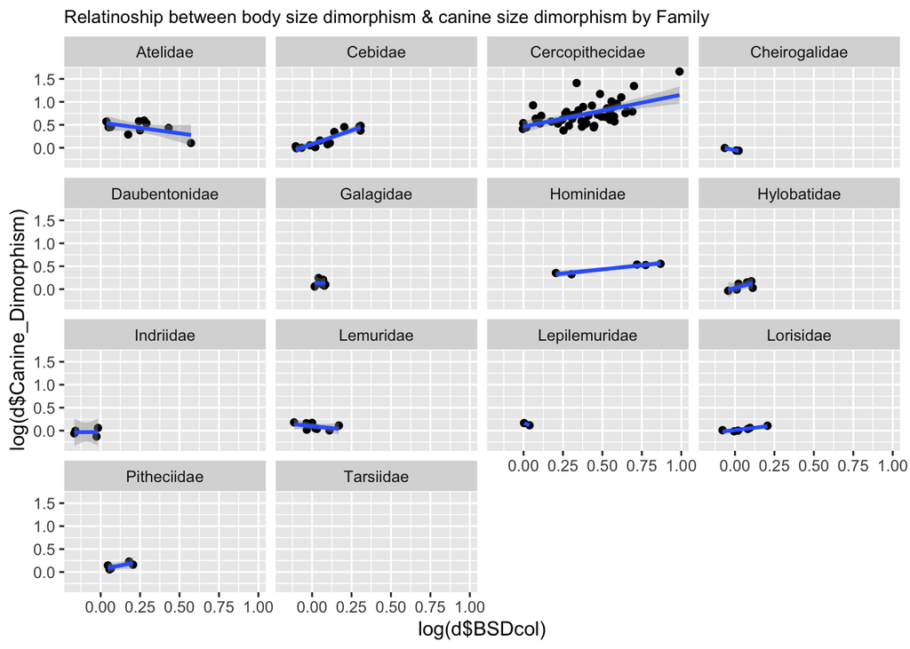

```r
d %>%
    ggplot(aes(x = log(d$BSDcol), y = log(d$Canine_Dimorphism))) +
    geom_point() + ggtitle ("Relatinoship between body size dimorphism & canine size dimorphism by Family") + theme(plot.title = element_text(size=10)) + facet_wrap(~Family, ncol = 4) + theme(legend.position = "none") + geom_smooth(method = "lm", fullrange = FALSE, na.rm = TRUE)
```

frugivore folivore omnivore

```r
d %>% mutate(diet = case_when(Fruit >= 50 ~ "frugivore", Leaves >= 50 ~ "folivore",
    Fruit < 50 & Leaves < 50 ~ "omnivore")) -> d
d
```

```
## # A tibble: 213 × 27
##    Scientific_Name             Family       Genus Species Brain_Size_Species_M…¹
##    <chr>                       <chr>        <chr> <chr>                    <dbl>
##  1 Allenopithecus_nigroviridis Cercopithec… Alle… nigrov…                   58.0
##  2 Allocebus_trichotis         Cercopithec… Allo… tricho…                   NA
##  3 Alouatta_belzebul           Atelidae     Alou… belzeb…                   52.8
##  4 Alouatta_caraya             Atelidae     Alou… caraya                    52.6
##  5 Alouatta_guariba            Atelidae     Alou… guariba                   51.7
##  6 Alouatta_palliata           Atelidae     Alou… pallia…                   49.9
##  7 Alouatta_pigra              Atelidae     Alou… pigra                     51.1
##  8 Alouatta_seniculus          Atelidae     Alou… senicu…                   55.2
##  9 Aotus_azarai                Cebidae      Aotus azarai                    20.7
## 10 Aotus_brumbacki             Cebidae      Aotus brumba…                   NA
## # ℹ 203 more rows
## # ℹ abbreviated name: ¹Brain_Size_Species_Mean
## # ℹ 22 more variables: Body_mass_male_mean <dbl>, Body_mass_female_mean <dbl>,
## #   MeanGroupSize <dbl>, AdultMales <dbl>, AdultFemale <dbl>,
## #   GR_MidRangeLat_dd <dbl>, Precip_Mean_mm <dbl>, Temp_Mean_degC <dbl>,
## #   HomeRange_km2 <dbl>, DayLength_km <dbl>, Fruit <dbl>, Leaves <chr>,
## #   Fauna <chr>, Canine_Dimorphism <dbl>, Feed <dbl>, Move <dbl>, Rest <dbl>, …
```

#8

```r
ss <- mutate(d, Binomial = paste(Genus, Species, sep = " ")) %>%
    select(Binomial, Family, Brain_Size_Species_Mean, Body_mass_male_mean) %>%
    group_by(Family) %>%
    summarise(avgF = mean(Brain_Size_Species_Mean, na.rm = TRUE), avgM = mean(Body_mass_male_mean,
        na.rm = TRUE)) %>%
    arrange(desc(avgF))
ss
```

```
## # A tibble: 14 × 3
##    Family            avgF   avgM
##    <chr>            <dbl>  <dbl>
##  1 Hominidae       410.   98681.
##  2 Hylobatidae     101.    6926.
##  3 Cercopithecidae  85.4   9543.
##  4 Atelidae         80.6   7895.
##  5 Pitheciidae      56.3   1955.
##  6 Daubentonidae    44.8   2620
##  7 Indriidae        27.3   3638.
##  8 Cebidae          23.9   1012.
##  9 Lemuridae        23.1   2077.
## 10 Lorisidae         8.67   512.
## 11 Lepilemuridae     7.27   792
## 12 Galagidae         5.96   395.
## 13 Cheirogalidae     4.04   193.
## 14 Tarsiidae         3.26   131
```